# Part II - (PROSPER LOAN DATA EXPLORATION)

## by (Gabriel Chidera Edeh)

## Investigation Overview

> The goal of this presentation will be to find out how some selected features in the dataset influence/ or is been influenced by the loan amount and prosper rating.

The key findings include;

> Majority of the listing and average loan requested for was for debt consolidation.

> More than half of the borrower were home owners and this set of people also topped the average loan original amount

> Highest percentage of the loan listing was carried out in the 4th quarter, followed by the 1st quarter

> Prosper rating AA which is the best rating is closly associated with low borrower rate between 0.05 and 0.10 while 25000 above loan original amount is associated with AA, A,B

## Dataset Overview

> This data set contains 113,937 loans with 81 variables on each loan, including loan amount, borrower rate (or interest rate), current loan status, borrower income, and many others

```python
# import all packages and set plots to be embedded inline
import numpy as np
import pandas as pd
import matplotlib.pyplot as plt
import seaborn as sb

%matplotlib inline

# suppress warnings from final output
import warnings
warnings.simplefilter("ignore")
```

```python
# load in the dataset into a pandas dataframe and make a copy of it
df = pd.read_csv('cleaned_prosperLoanData.csv')
loan_data = df.copy()
```

## (Visualization 1)

> How is income range of the borrower related to a successful loan listing?

```python
def univar_barchart(column,kind,size=None,sort=None):
    if size is None:
        plt.figure(figsize=[15,8])
    else:
        plt.figure(figsize=size)

    # for feature vs record count

    if sort == True:
        plt.subplot(1, 2, 1)
        loan_data.groupby(column)["LoanOriginalAmount"].count().sort_values(ascending=False).plot(kind=kind);
        plt.ylabel("record count")
        plt.title(f"{column}  vs record count");

        # for feature vs Average LoanOriginalAmount
        plt.subplot(1, 2, 2)
        loan_data.groupby(column)["LoanOriginalAmount"].mean().sort_values(ascending=False).plot(kind=kind,color="red");
        plt.ylabel("Average LoanOriginalAmount")
        plt.title(f"{column}   vs Average LoanOriginalAmount");
    else:
        plt.subplot(1, 2, 1)
        loan_data.groupby(column)["LoanOriginalAmount"].count().plot(kind=kind);
        plt.ylabel("record count")
        plt.title(f"{column}  vs record count");

        # for feature vs Average LoanOriginalAmount
        plt.subplot(1, 2, 2)
        loan_data.groupby(column)["LoanOriginalAmount"].mean().plot(kind=kind,color="red");
        plt.ylabel("Average LoanOriginalAmount")
        plt.title(f"{column}   vs Average LoanOriginalAmount");
```

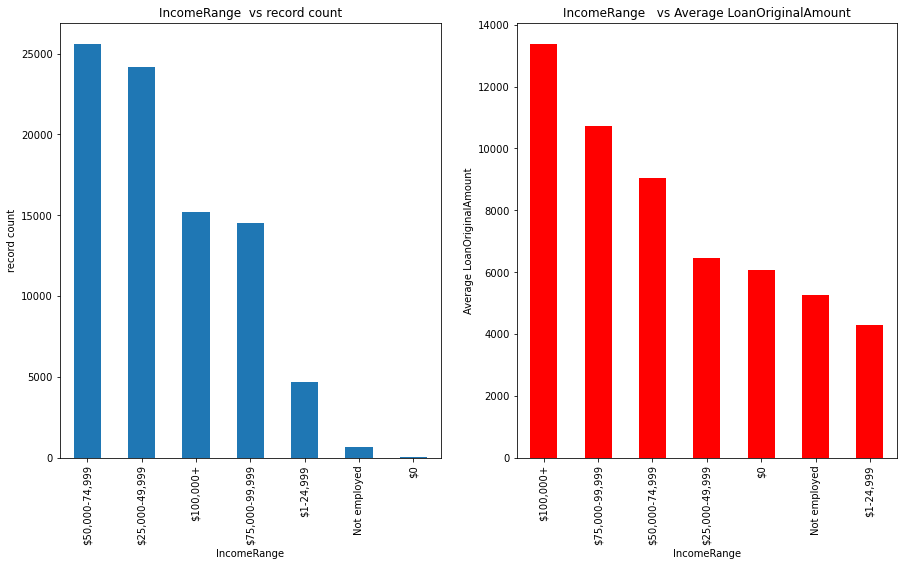

```python
univar_barchart('IncomeRange',"bar", sort = True)
```

## (Visualization 2)

How is the Listing Category related to the LoanOriginalAmount?

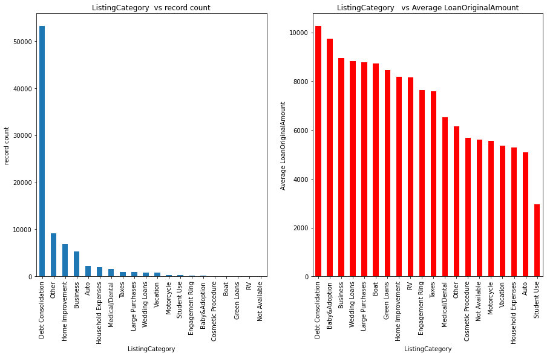

```python
univar_barchart('ListingCategory',"bar", sort = True)
```

> Majority of the listing and average loan requested for was for debt consolidation.

## (Visualization 3)

> How does being a homeowner related to being loan listed?

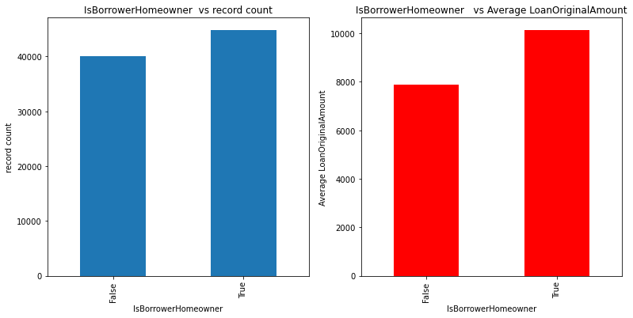

```python
univar_barchart('IsBorrowerHomeowner',"bar", [13,6])
```

> More than half of the borrower were home owners and this set of people also topped the average loan original amount

### (Visualization 4)

> Which Quarter of the year recorded the highest loan listing?

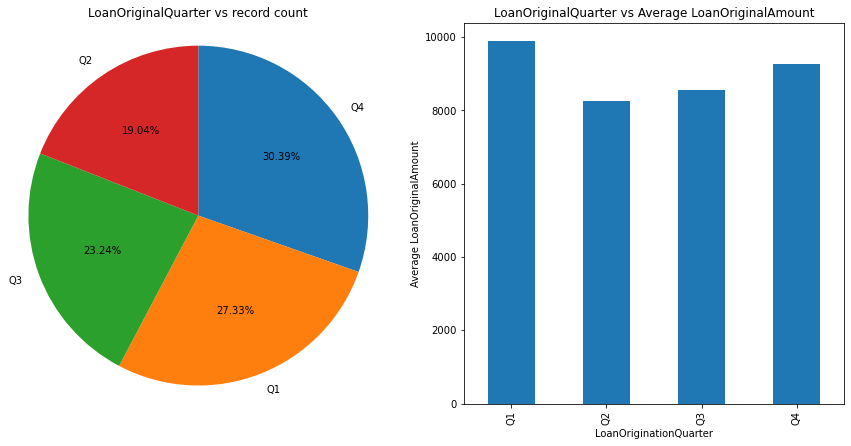

```python
sorted_counts = loan_data.LoanOriginationQuarter.value_counts()
plt.figure(figsize=[15,7])


# plot for LoanOriginalQuarter vs record count
plt.subplot(1, 2, 1)
plt.pie(sorted_counts, labels = sorted_counts.index, startangle = 90, counterclock = False,autopct='%1.2f%%');
plt.axis('square')
plt.title("LoanOriginalQuarter vs record count");

# for LoanOriginalQuarter vs Average LoanOriginalAmount
plt.subplot(1, 2, 2)
loan_data.groupby("LoanOriginationQuarter")["LoanOriginalAmount"].mean().plot(kind="bar");
plt.ylabel("Average LoanOriginalAmount")
plt.title("LoanOriginalQuarter vs Average LoanOriginalAmount");
```

> Highest percentage of the loan listing was carried out in the 4th quarter, followed by the 1st quarter and lastly by the 2nd quarter of the year, with the 1st quarter recording the highest average loan amount for the years the survey was carried out

### (Visualization 5)

> How is borrower rate, Original loan amount and Prosper rating related to each other?

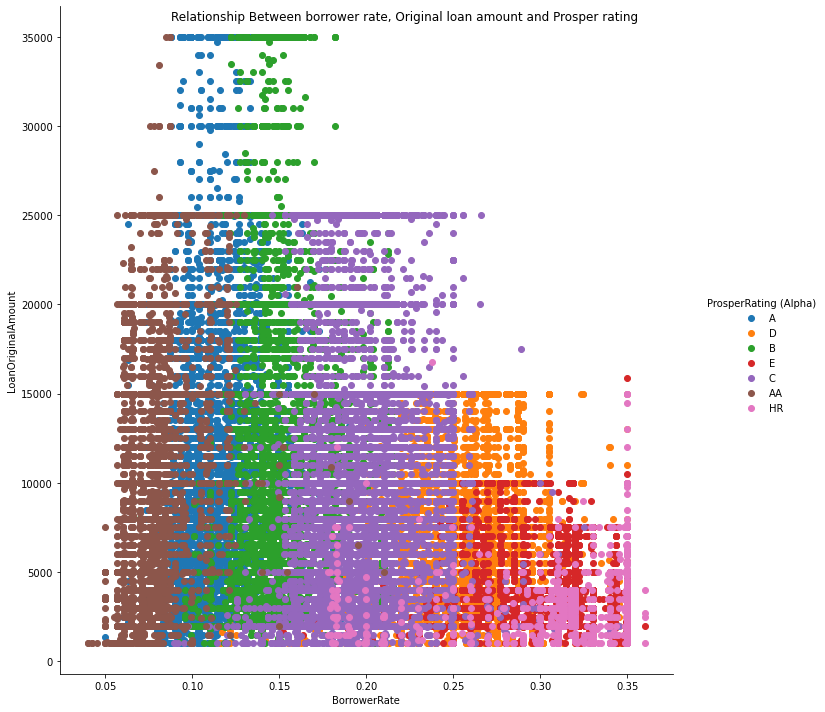

```python
g = sb.FacetGrid(data =loan_data, hue = 'ProsperRating (Alpha)', height = 10, margin_titles=True)
g.map(plt.scatter, 'BorrowerRate', 'LoanOriginalAmount')
g.add_legend();
g.fig.suptitle('Relationship Between borrower rate, Original loan amount and Prosper rating');
```

> Prosper rating AA which is the best rating is closly associated with low borrower rate between 0.05 and 0.10 while 25000 above loan original amount is associated with AA, A,B